# HW4

## Question 2

### (a) Write down the formula for the unnormalized posterior of $\beta | Y$

### Solution:

We are given the data $(X,Y)$, with $X \in R^d$ and $Y \in \{0,1\}$. To train the classifier, we have the following model
$$Y \sim Ber\left(\frac{1}{1 + e^{-X^T \beta}}\right)$$
$$X \sim N(0, \sigma^2 I)$$

Now, we need to write the formula of unnormalized posterior of $\beta | Y$ i.e.
$$p(\beta | y; x, \sigma) \propto \prod_{i=1}^{n} p(y_i | \beta; x_i) p(\beta; \sigma)$$

Now, to find this, we will first write the two terms in the product individually. So for $p(y_i | \beta; x_i)$ we can compute it using the properties of a bernoulli random variable. So we have,

$$p(y_i | \beta; x_i) = \left(\frac{1}{1 + e^{-x_i^T \beta}}\right)^{y_i} \left(1 - \frac{1}{1 + e^{-x_i^T \beta}}\right)^{1- y_i}$$

Similarly, we have,
$$p(\beta, \sigma) \propto e^{\frac{-||\beta||^2}{2 \sigma^2}}$$

Now, putting these two values together in the original unnormalized posterior formula, we have,

$$p(\beta | y; x, \sigma) \propto e^{\frac{-||\beta||^2}{2 \sigma^2}} \cdot \left[\prod_{i=1}^{n}\left(\frac{1}{1 + e^{-x_i^T \beta}}\right)^{y_i} \left(1 - \frac{1}{1 + e^{-x_i^T \beta}}\right)^{1- y_i} \right]$$

### (b) Show that this posterior is proportional to exp(-U(beta)).

### Solution:

Here, we have to show that the posterior computed in the previous question is proportional to $exp(-U(\beta))$ where $U(\beta)$ is defined as:
$$U(\beta) = \sum_{i=1}^{n} (1 - y_i)x_i^T\beta + \log (1 + e^{-x_i^T \beta}) + \frac{1}{2\sigma ^2} ||\beta||^2$$

So, in order to prove this statement we will assume that $e^{-U(\beta)}$ is indeed equivalent to the posterior. We are gonna skip the proportionality constant in this case because it doesn’t affect the proof. Then we will show that the $U(\beta)$ that we get now satisfies the aforementioned equation. Therefore, let us assume,

$$\begin{align*}
e^{-U(\beta)} &= e^{\frac{-||\beta||^2}{2 \sigma^2}} \cdot \left[\prod_{i=1}^{n}\left(\frac{1}{1 + e^{-x_i^T \beta}}\right)^{y_i} \left(1 - \frac{1}{1 + e^{-x_i^T \beta}}\right)^{1- y_i} \right] \\
&\text{Taking natural log of this equation} \\
-U(\beta) &= \frac{-||\beta||^2}{2 \sigma^2} + \left[\sum_{i=1}^{n}y_i \log \left(\frac{1}{1 + e^{-x_i^T \beta}}\right) + (1 - y_i) \log \left(1 - \frac{1}{1 + e^{-x_i^T \beta}}\right)\right] \\
-U(\beta) &= \frac{-||\beta||^2}{2 \sigma^2} + \left[\sum_{i=1}^{n} -y_i \log \left(1 + e^{-x_i^T \beta}\right) + (1 - y_i) \log \left(\frac{e^{-x_i^T \beta}}{1 + e^{-x_i^T \beta}}\right)\right] \\
-U(\beta) &= \frac{-||\beta||^2}{2 \sigma^2} + \left[\sum_{i=1}^{n} -y_i \log \left(1 + e^{-x_i^T \beta}\right) + (1 - y_i) \left( \log \left(e^{-x_i^T \beta} \right) - \log \left(1 + e^{-x_i^T \beta}\right)\right)\right] \\
U(\beta) &= \frac{||\beta||^2}{2 \sigma^2} + \left[\sum_{i=1}^{n} y_i \log \left(1 + e^{-x_i^T \beta}\right) - (1 - y_i) \log \left(e^{-x_i^T \beta} \right) + (1 - y_i) \log \left(1 + e^{-x_i^T \beta}\right)\right] \\
U(\beta) &= \frac{||\beta||^2}{2 \sigma^2} + \left[\sum_{i=1}^{n} \log \left(1 + e^{-x_i^T \beta}\right) + (1 - y_i) x_i^T \beta\right] \\
\end{align*}$$

So we can see that it matches the original equation of $U(\beta)$, hence our assumption was right.

### (c), (d), (e), and (f)

The code below contains the entire code for the parts aforementioned. I have added comments in between to demonstrate what a particular piece of code is doing. Please refer to the cat statements and comments in between. The results are summarized below before the code.

#### c)

The implementation of Hamiltonian Monte Carlo can be found in the code below. This code is derived from Radford-Neal Paper. Also, to ease up the process, we are labelling virginica as 0 and versicolor as 1.

#### d)

Firstly, the dataset is divided into training and testing datasets. Then, we are generating 11000 samples of beta which contains 1000 for burn-in and 10000 for the testing stage. We are also seeing that we are getting acceptance rate of ~98%. Now, for each sampled beta, we are computing a label for it. To compute a label, we are rounding up the probability to get the label. Following the aforementioned method, I got a classification accuracy of 97.5% for predicting the $y$ labels.

#### e)

The trace plots and histogram for the 4 features and one constant features can be found at the end of code.

## CODE

```r
#source("HamiltonianMonteCarlo.r", echo = FALSE, keep.source = FALSE, max.deparse.length=10000)
require(animation)
```

```r
## Load and Store the data to use for the given question
dataset = iris
dataset = subset(dataset, Species != "setosa")

# if(dataset$Species == "versicolor"){
#   dataset$Species = 1
# } else{
#   dataset$Species = 0
# }

#the upper solution was not working so found one alternative to that on StackOverflow
# Mapping the versicolor to 1 and virginica to 0
dataset$Species = ifelse(dataset$Species == "versicolor", 1, 0)

## Debugging Statements
#print(dataset)
#dataset = as.matrix(dataset)
#print(dataset[,1])

# Seperate the dataset into features and labels
X = t(as.matrix(cbind(dataset[1:4], 1)))
Y = as.matrix(dataset[5])

#print(X[,1:30])

#print(t(rowMeans(X)))
#print(Y)

# Seperate the training and testing datasets
X_Train = matrix(0.0, 5, 60)
X_Test = matrix(0.0, 5, 40)
#print(dim(X_Train))

Y_Train = matrix(0.0, 60, 1)
Y_Test = matrix(0.0, 40, 1)

# For each species, first 30 rows will be training data and the rest 20 will be testing data
X_Train[,1:30] = X[,1:30]
X_Test[,1:20] = X[,31:50]
X_Train[,31:60] = X[,51:80]
X_Test[,21:40] = X[,81:100]

Y_Train[1:30,] = Y[1:30,]
Y_Test[1:20,] = Y[31:50,]
Y_Train[31:60,] = Y[51:80,]
Y_Test[21:40,] = Y[81:100,]

X_Train = X_Train - rowMeans(X_Train)
X_Test = X_Test - rowMeans(X_Test)
#
# print(X_Train)
# print(X_Test)

# initializing the beta, sigma and reject counter
beta_i = matrix(0.0,5,1)
sigma_i = 1
reject_counter = 0

#### Main methods start from here ####


# Method to calculate the norm of the beta vector
beta_norm = function(beta){
  temp = as.vector(beta)
  temp = sqrt(sum(temp * temp))
  return(temp)
}

# The energy function
U = function(beta = beta_i, sigma = sigma_i, data = X_Train, labels = Y_Train){
  temp_beta = beta_norm(beta)
  temp_mul = t(data) %*% beta
  temp_U = t(1 -labels) %*% temp_mul + sum(log(1+exp(-temp_mul)))  + (1 / 2 * sigma^2) * temp_beta^2
  return (temp_U)
}

# Gradient of the energy function
grad_U = function(beta = beta_i, sigma = sigma_i, data = X_Train, labels = Y_Train){
  temp_mul = t(data) %*% beta
  temp_mat = 1 - (exp(-temp_mul)/(1 + exp(-temp_mul))) - labels
  temp_gradient = data %*% temp_mat + ((1/sigma^2)*beta)
  return(temp_gradient)
}

## Code for Q.2c i.e. implementation of Hamiltonian Monte Carlo routine for sampling from the posterior of Beta
## Code from Radford Neal's paper (slightly modified)

HMC = function (U, grad_U, epsilon, L, current_q, anim = FALSE)
{
  q = current_q
  p = rnorm(length(q),0,1) # independent standard normal variates
  current_p = p

  qList = q
  pList = p

  ## Make a half step for momentum at the beginning
  p = p - epsilon * grad_U(q) / 2

  ## Alternate full steps for position and momentum
  for(i in 1:(L-1))
  {
    ## Make a full step for the position
    q = q + epsilon * p

    ## Make a full step for the momentum, except at end of trajectory
    p = p - epsilon * grad_U(q)

    if(anim)
    {
      H = function(x, y) { U(x) + 0.5 * y^2 }

      t = seq(-2, 2, 0.01)
      Hvals = outer(t, t, H)
      contour(t, t, Hvals, levels=seq(0, 3, 0.1), asp=1,
              drawlabel=FALSE, xlab="q", ylab="p")
      lines(qList, pList, lwd=2, col='red')
      ani.record()
      pList = c(pList, p)
      qList = c(qList, q)
    }
  }

  q = q + epsilon * p

  ## Make a half step for momentum at the end.
  p = p - epsilon * grad_U(q) / 2

  ## Negate momentum at end of trajectory to make the proposal symmetric
  p = -p

  ## Evaluate potential and kinetic energies at start and end of trajectory
  current_U = U(current_q)
  current_K = sum(current_p^2) / 2
  proposed_U = U(q)
  proposed_K = sum(p^2) / 2

  ## Accept or reject the state at end of trajectory, returning either
  ## the position at the end of the trajectory or the initial position
  if(current_U + current_K > proposed_U + proposed_K)
    return(q) # reject
  else if (runif(1) < exp(current_U-proposed_U+current_K-proposed_K))
    return (q) # accept
  else{
    reject_counter <<- reject_counter + 1
    return (current_q) # reject
  }
}

# Driver function to run Hamiltonian Monte Carlo
HMC_util = function(epsilon, L, samples, burn){
  reject = 0
  beta = beta_i

  # starting with the burn-in samples
  for(i in 1:burn){
    beta = HMC(U, grad_U, epsilon, L, beta)
  }

  beta_l = matrix(0.0, samples, 5)
  beta_l[1,] = beta

  # Start with the samples/iterations
  it = samples - 1
  beta_updated = beta

  for(i in 1:it){
    beta_updated = HMC(U, grad_U, epsilon, L, beta_updated)
    temp = beta - beta_updated

    # if(beta_norm(temp) < 0.0001){
    #   reject = reject + 1
    # }
    beta_l[i,] = beta_updated
  }
  accept_percent = (1 - (reject_counter/samples))*100

  cat("Acceptance Rate is ", accept_percent, "\n")
  return(beta_l)
}

## Generating Plots - Trace Plots and Histogram

trace_beta = function(beta, ftr_num, feature){
  row = dim(beta)[1]
  plot(1:row, beta[,ftr_num], lwd = 1, type = 'l', col = 'blue', main="Trace Plot", xlab = "Samples", ylab = paste("Beta for ", feature, sep = ""))
}

hist_plot = function(beta, ftr_num, feature){
  temp = beta[,ftr_num]
  hist(temp, freq = FALSE, breaks = 75, col= "blue",main = "Histogram", xlab = "Samples", ylab = paste("Beta for ", feature, sep = ""))
}

## Classification process

classifier = function(sample_beta, testing = X_Test){

  data_points = dim(testing)[2]
  sample_count = dim(sample_beta)[1]
  updated_labels = matrix(0, data_points, 1)
  probability_matrix = matrix(0, data_points, 1)

  # loop through all the values and chose one label for each beta by prediction
  for (i in 1:sample_count) {
    beta = sample_beta[i,]
    temp_mat = t(testing) %*% beta
    temp_prob = 1 + exp(-temp_mat)
    probability_matrix = probability_matrix + (1/temp_prob)
  }

  probability_matrix = probability_matrix/sample_count
  updated_labels[probability_matrix > 0.5] = 1
  return(probability_matrix)
}

# To get the average prediction
average_classifier = function(sample_beta, testing = X_Test){

  data_points = dim(testing)[2]
  sample_count = dim(sample_beta)[1]
  average_beta = colMeans(sample_beta)
  updated_labels = matrix(0, data_points, 1)
  probability_matrix = matrix(0, data_points, 1)
  temp_mat = t(testing) %*% average_beta
  temp_prob = 1 + exp(-temp_mat)
  probability_matrix = probability_matrix + (1/temp_prob)
  updated_labels[probability_matrix > 0.5] = 1
  return(updated_labels)
}

# To get the Monte Carlo estimate of the Posterior Predictive probability
posterior_probability = function(sample_beta, testing = X_Test){
  data_points = dim(testing)[2]
  sample_count = dim(sample_beta)[1]
  probability_matrix = matrix(0, data_points, 1)

  for(i in 1:sample_count){
    beta = sample_beta[i,]
    temp_mat = t(testing) %*% beta
    probability_matrix = probability_matrix + (1/(1 + exp(-temp_mat)))
  }
  probability_matrix = probability_matrix/sample_count
  return(probability_matrix)
}

# Code to get the accuracy of classification
testing_classification_accuracy = function(labels_predicted, labels_true = Y_Test){
  data_count = dim(labels_predicted)[1]
  temp = matrix(0, data_count, 1)
  temp[labels_predicted == labels_true] = 1
  accuracy = (sum(temp)/data_count)*100
  cat("The accuracy for classification is ", accuracy, "\n")
}

## Driver for Question 2

# Question 1c.

# Sample the 10000 samples of beta with epsilon = 0.2, L = 20, burn-in = 1000
sample_beta = HMC_util(0.2, 20, 10000, 1000)
```

```
## Acceptance Rate is  98.24
```

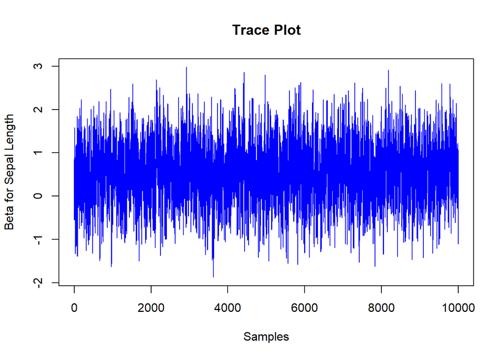

```r
#print(sample_beta)

## Question 1e

## Draw Trace Plots and Histograms of all the 5 variables (i.e. 1D constants)
trace_beta(sample_beta, 1, "Sepal Length")
```

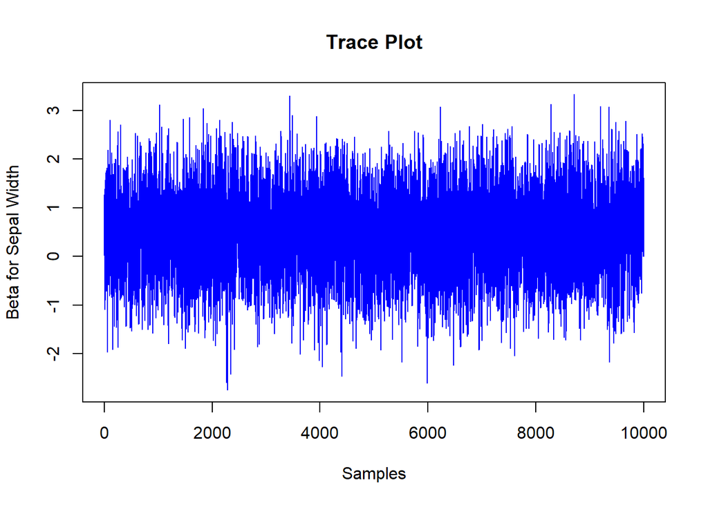

```r
trace_beta(sample_beta, 2, "Sepal Width")
```

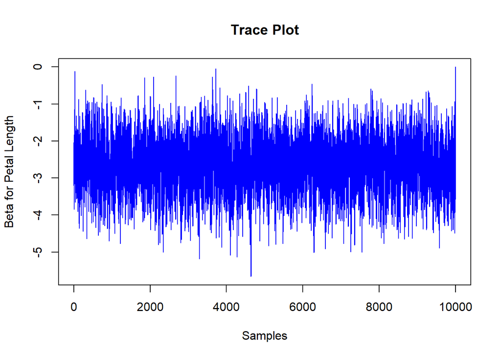

```r
trace_beta(sample_beta, 3, "Petal Length")
```

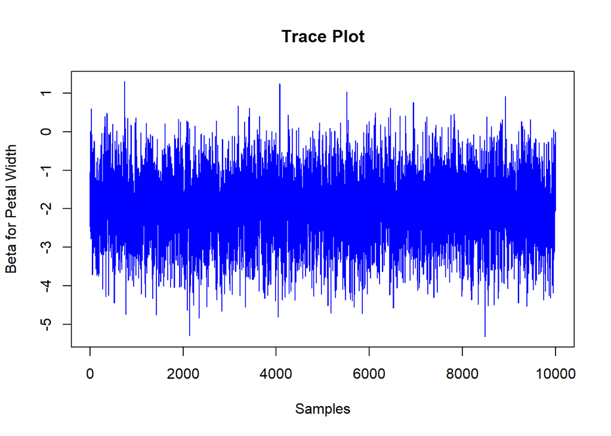

```r
trace_beta(sample_beta, 4, "Petal Width")
```

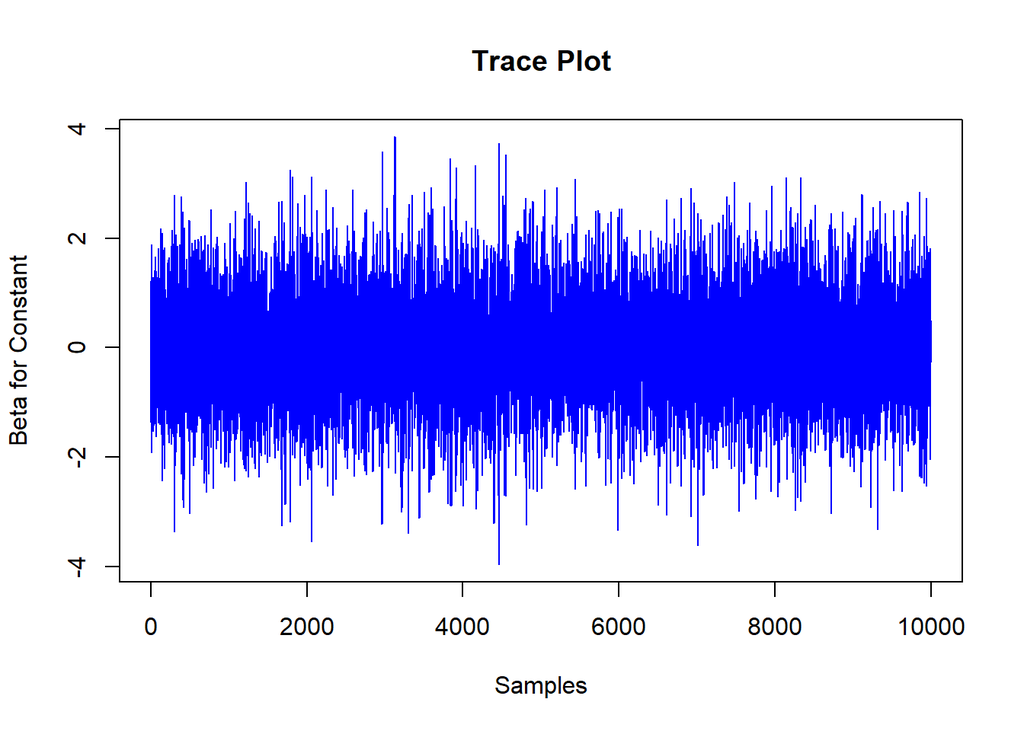

```r
trace_beta(sample_beta, 5, "Constant")
```

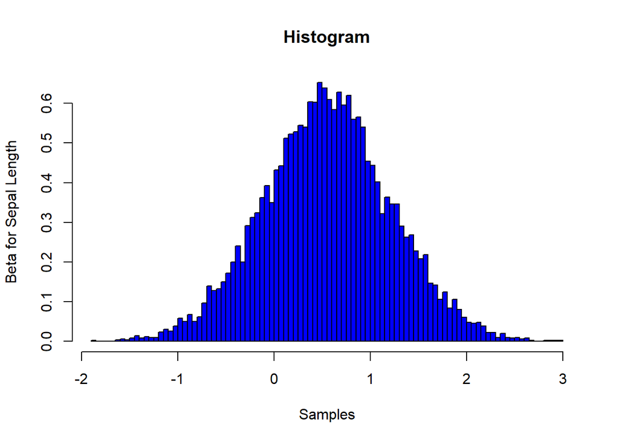

```r
hist_plot(sample_beta, 1, "Sepal Length")
```

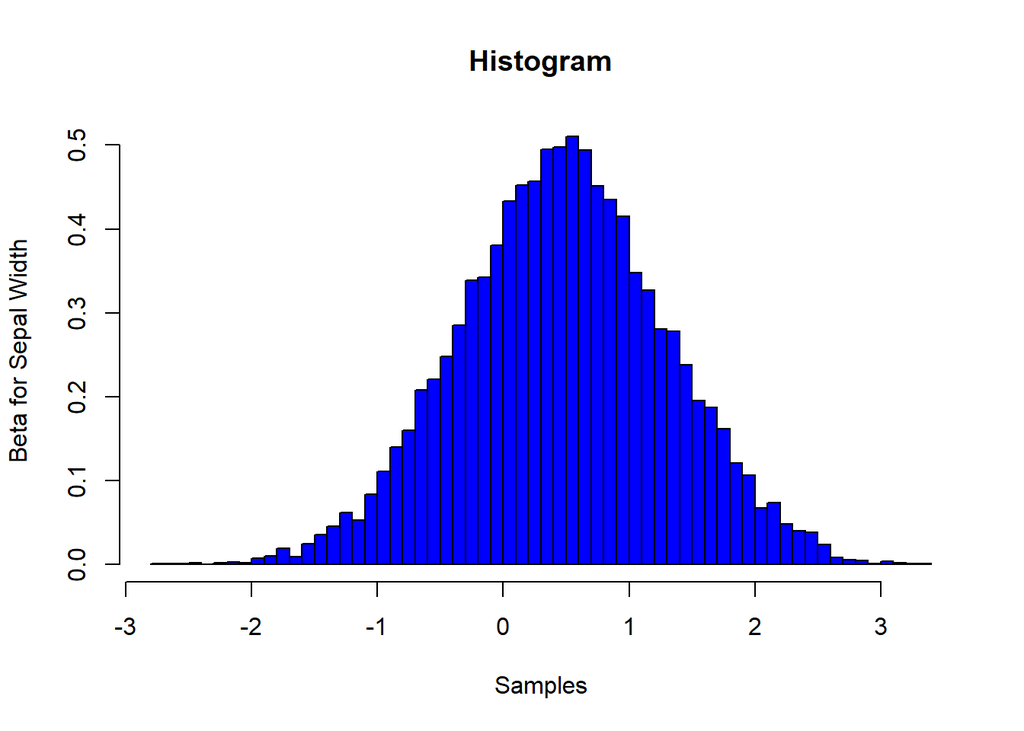

```r
hist_plot(sample_beta, 2, "Sepal Width")
```

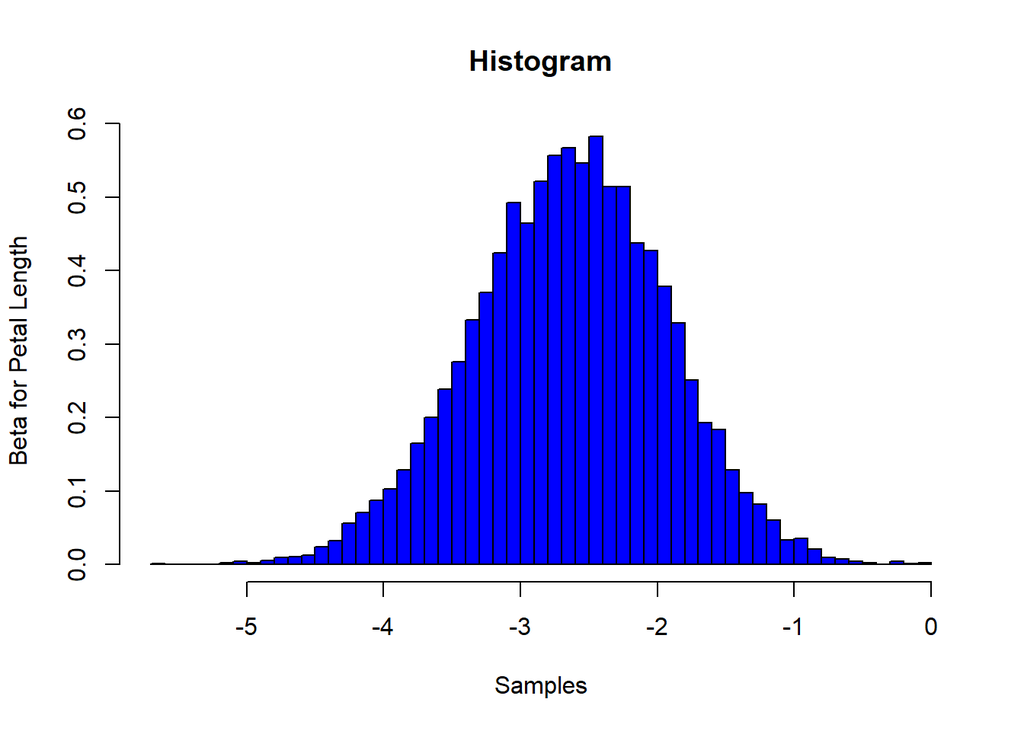

```r
hist_plot(sample_beta, 3, "Petal Length")
```

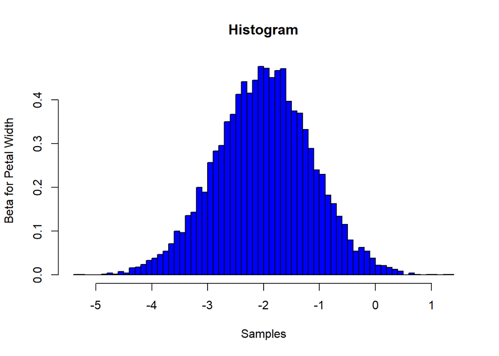

```r
hist_plot(sample_beta, 4, "Petal Width")
```

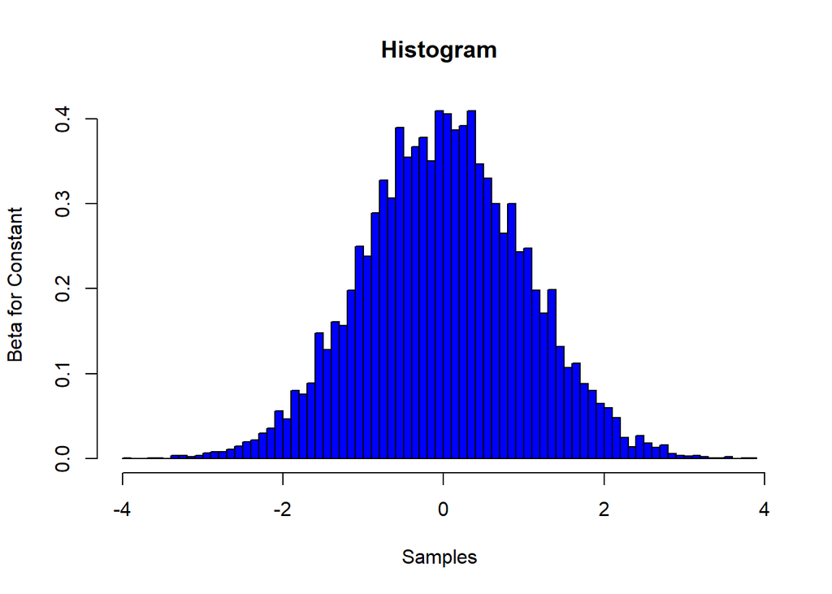

```r
hist_plot(sample_beta, 5, "Constant")
```

```r
#print(sample_beta)
#print(sample_beta[,1])

## Question 1d.

## Get the prediction for y of the class labels for the testing data
prediction = classifier(sample_beta)
prediction = round(prediction)
#print(Y_Test)

cat("For the predicted labels, the accuracy of classification is calculated here\n")
```

```
## For the predicted labels, the accuracy of classification is calculated here
```

```r
testing_classification_accuracy(prediction)
```

```
## The accuracy for classification is  97.5
```

```r
cat("The posterior predictive probability for each testing data point \n")
```

```
## The posterior predictive probability for each testing data point
```

```r
posterior = posterior_probability(sample_beta)
print(posterior)
```

```
##             [,1]
##  [1,] 0.95158971
##  [2,] 0.96733833
##  [3,] 0.94808040
##  [4,] 0.31389589
##  [5,] 0.67904818
##  [6,] 0.74259230
##  [7,] 0.73009004
##  [8,] 0.81960831
##  [9,] 0.90435797
## [10,] 0.90012572
## [11,] 0.80811746
## [12,] 0.75045666
## [13,] 0.93174877
## [14,] 0.98057982
```

[output cut: 26 more lines]

```r
## Question 1f.

## Do for the average classification
cat("For the average classification, the accuracy of classification is \n")
```

```
## For the average classification, the accuracy of classification is
```

```r
prediction_avg = average_classifier(sample_beta)
prediction_avg = round(prediction_avg)
testing_classification_accuracy(prediction_avg)
```

```
## The accuracy for classification is  97.5
```